# 685.701 Data Science: Modeling & Analytics — Programming Assignment 1

**Use this notebook to complete PA1.**

# Fill before submitting

- **Student:** `Zach Hatzenbeller`
- **JHED/Email:** `zhatzen1@jh.edu`
- **Selected optional problem (choose exactly one):** ☑ Problem 3 ☐ Problem 4 ☐ Problem 5
- **Course:** `Data Science Modeling & Analytics`
- **Date:** `2025-10-12`
- **Instructor:** `Ben Rodriguez, PhD`

## Submission Instructions and Problem Selection

**Problems 1 and 2 are required.** In addition, complete *exactly one* of Problems **3, 4, or 5**. Clearly indicate which optional problem you selected at the top of your submission. Unless otherwise noted, use Python and follow standard notebook practices (pseudocode → code → analysis → conclusions). A great starting point/reference is the use of the homework notebooks provided.

While student discussions, sharing of recommendations, and some collaboration are encouraged for team building and peer learning, **each student is required to submit their own complete programming solutions.** Every submission must demonstrate the individual student’s ability to design, document, implement in code, and test their work independently.

The programming language is Python. Please follow standard Python programming guidelines.

**Grading Criteria (100% for this problem):**

- **Completeness & Problem Coverage (20%)** — Pseudocode → code → performance analysis → outputs; nothing missing.
- **Writing Quality, Technical Accuracy & Justification (20%)** — Clear, concise, technically correct; justify design choices.
- **Quantitative Work: Assumptions, Derivations & Calculations (20%)** — List assumptions before coding; show formulas/metrics; correct, well-presented results.
- **Code Quality, Documentation & Execution (20%)** — Notebook runs end-to-end; clean names/formatting/comments; organized and reproducible.
- **Examples, Test Cases & Visuals (10%)** — Labeled test cases; informative figures/tables; use precision, recall, F1, ROC/PR (not accuracy alone).
- **Notebook README & Reproducibility (10%)** — Python version, package list & install steps; dataset details; run instructions; relative paths & fixed seeds.

## README (Execution & Setup)

**Use this section to make your notebook reproducible.**

- **Python version:** `3.11.1`
- **Required packages:** `numpy`, `pandas`, `scikit-learn`, `matplotlib`, `seaborn`, `hdbscan`
- **Install instructions (if non-standard):**

  ```
  # Example (uncomment & run in a terminal if needed)
  # pip install -r requirements.txt
  # or
  # pip install numpy pandas scikit-learn matplotlib seaborn hdbscan
  ```

**README hint**: Place `creditcard.csv` in `./data/` (or set `DATA_PATH` below). The dataset can be downloaded from Kaggle. Due to size limits, keep only relative paths in this notebook.

## References (mirrors PA1.tex)

The LaTeX version uses **biblatex** with `\addbibresource{bibliographies.bib}` and renders references with `\printbibliography`. The following BibTeX keys are cited within PA1:

- `Hastie2009`, `Bishop2006`, `Pedregosa2011`, `Fawcett2006`
- `breiman_2001`, `cortes1995support`
- `macqueen1967some`, `rousseeuw1987silhouettes`, `calinski1974dendrite`, `Dempster1977`
- `Vaswani2017`, `wolf2020transformers`, `brockman2016openai`, `sutton2018reinforcement`
- `He2016`, `Krizhevsky2012`, `huggingface_transformers`

> **Note:** When submitting this notebook, keep your narrative and citations inline here.

## Setup

```python
# Reproducibility: set global seeds and print versions
import os, random, sys, json, time, math
import numpy as np

SEED = 42
random.seed(SEED)
np.random.seed(SEED)

print('Python:', sys.version)
print('Seed set to:', SEED)
```

```
Python: 3.11.1 (tags/v3.11.1:a7a450f, Dec  6 2022, 19:58:39) [MSC v.1934 64 bit (AMD64)]
Seed set to: 42
```

# Problem 1 — Preprocessing (Required) — Modules 1, 2, and 3

**20 points total.**

Develop a robust **classification pipeline** to predict a target event using a structured dataset of your choice (approved public datasets encouraged; e.g., Kaggle or Hugging Face Datasets). Your workflow should explicitly follow Modules 2–3: collection, cleaning, transformation, outlier handling; feature engineering/ranking/selection; dimensionality reduction; and principled data splitting. Provide a concise dataset description (features, target, size, splits) and include either the dataset (if licensing allows) or a reproducible link/instructions.

**Implementation notes (align with Modules 2–3):**

- Use **Stratified** train/validation/test splits for classification; fix and report your random seed.
- **Avoid leakage**: fit any scalers/encoders/imputers on **train** only; apply to validation/test unchanged.
- Handle **duplicates, missing values, and outliers** (e.g., IQR-based rules) and justify your choices.
- Choose **transformations** thoughtfully (standardization vs normalization; categorical encoding via OneHotEncoder; date/time features) and explain the impact on downstream models.
- Ensure **reproducibility**: relative paths, seeds, environment/package versions, and minimal end-to-end run steps.

## 1(a) Data retrieval — 5 points

Obtain, cite, and briefly summarize the dataset. Identify the target variable. Perform a principled split into train/validation/test (e.g., 70/15/15 or stratified k-fold CV for model selection plus a held-out test). State the seed and rationale for the split design.

## 1(b) Data quality & cleaning — 5 points

Describe and apply cleaning steps (duplicates, missingness, incorrect entries). Show summary statistics and sanity checks. Identify potential outliers; justify your treatment (e.g., IQR thresholds; compare robustness with/without outliers).

## 1(c) Feature preprocessing — 10 points

Apply appropriate transforms (standardization/normalization; OneHotEncoder; date-time handling). Show pre/post distributions, and ensure all transforms are fit on **train** and applied unchanged to **validation/test** to avoid leakage. If you use any feature ranking/selection or dimensionality reduction prior to modeling, specify where it occurs in the pipeline and why (e.g., PCA for visualization vs supervised selection embedded in a model).

### Recommended public datasets (choose one; works for both Supervised and Unsupervised problems)

- **Hugging Face — `adult` (Census Income):** classic structured classification (predict $50K+); mix of categorical + numeric. Unsupervised: cluster socioeconomic profiles or anomaly detection.
- **Hugging Face — `covertype`:** large tabular dataset predicting forest cover type; good for preprocessing and scalability. Unsupervised: eco-region clustering; internal indices across *k*.
- **Kaggle — Telco Customer Churn:** rich categorical signals; good for encoding, imputation, and class-imbalance handling. Unsupervised: customer segmentation.
- **Kaggle — Credit Card Fraud Detection:** highly imbalanced; ideal for careful scaling and PR curves. Unsupervised: anomaly detection baseline.

### 1A. Data Retrieval

```python
import pandas as pd
import kagglehub

# Download latest version
path = kagglehub.dataset_download("mlg-ulb/creditcardfraud")
print("Path to dataset files:", path)

target_variable = "Class"

df = pd.read_csv(os.path.join(path, "creditcard.csv")).drop(columns=["Time"], axis=1)
print("Dataset shape:", df.shape)
display(df.head())
```

```
Path to dataset files: C:\Users\zhatz\.cache\kagglehub\datasets\mlg-ulb\creditcardfraud\versions\3
Dataset shape: (284807, 30)
```

|  | V1 | V2 | V3 | V4 | V5 | V6 | V7 | V8 | V9 | V10 | ... | V21 | V22 | V23 | V24 | V25 | V26 | V27 | V28 | Amount | Class |
| --- | --- | --- | --- | --- | --- | --- | --- | --- | --- | --- | --- | --- | --- | --- | --- | --- | --- | --- | --- | --- | --- |
| 0 | -1.359807 | -0.072781 | 2.536347 | 1.378155 | -0.338321 | 0.462388 | 0.239599 | 0.098698 | 0.363787 | 0.090794 | ... | -0.018307 | 0.277838 | -0.110474 | 0.066928 | 0.128539 | -0.189115 | 0.133558 | -0.021053 | 149.62 | 0 |
| 1 | 1.191857 | 0.266151 | 0.166480 | 0.448154 | 0.060018 | -0.082361 | -0.078803 | 0.085102 | -0.255425 | -0.166974 | ... | -0.225775 | -0.638672 | 0.101288 | -0.339846 | 0.167170 | 0.125895 | -0.008983 | 0.014724 | 2.69 | 0 |
| 2 | -1.358354 | -1.340163 | 1.773209 | 0.379780 | -0.503198 | 1.800499 | 0.791461 | 0.247676 | -1.514654 | 0.207643 | ... | 0.247998 | 0.771679 | 0.909412 | -0.689281 | -0.327642 | -0.139097 | -0.055353 | -0.059752 | 378.66 | 0 |
| 3 | -0.966272 | -0.185226 | 1.792993 | -0.863291 | -0.010309 | 1.247203 | 0.237609 | 0.377436 | -1.387024 | -0.054952 | ... | -0.108300 | 0.005274 | -0.190321 | -1.175575 | 0.647376 | -0.221929 | 0.062723 | 0.061458 | 123.50 | 0 |
| 4 | -1.158233 | 0.877737 | 1.548718 | 0.403034 | -0.407193 | 0.095921 | 0.592941 | -0.270533 | 0.817739 | 0.753074 | ... | -0.009431 | 0.798278 | -0.137458 | 0.141267 | -0.206010 | 0.502292 | 0.219422 | 0.215153 | 69.99 | 0 |

5 rows × 30 columns

### 1b. Data Quality and Cleaning

```python
# Summary statistics and info
display(df.describe())
display(df.info())
```

|  | V1 | V2 | V3 | V4 | V5 | V6 | V7 | V8 | V9 | V10 | ... | V21 | V22 | V23 | V24 | V25 | V26 | V27 | V28 | Amount | Class |
| --- | --- | --- | --- | --- | --- | --- | --- | --- | --- | --- | --- | --- | --- | --- | --- | --- | --- | --- | --- | --- | --- |
| count | 2.848070e+05 | 2.848070e+05 | 2.848070e+05 | 2.848070e+05 | 2.848070e+05 | 2.848070e+05 | 2.848070e+05 | 2.848070e+05 | 2.848070e+05 | 2.848070e+05 | ... | 2.848070e+05 | 2.848070e+05 | 2.848070e+05 | 2.848070e+05 | 2.848070e+05 | 2.848070e+05 | 2.848070e+05 | 2.848070e+05 | 284807.000000 | 284807.000000 |
| mean | 1.168375e-15 | 3.416908e-16 | -1.379537e-15 | 2.074095e-15 | 9.604066e-16 | 1.487313e-15 | -5.556467e-16 | 1.213481e-16 | -2.406331e-15 | 2.239053e-15 | ... | 1.654067e-16 | -3.568593e-16 | 2.578648e-16 | 4.473266e-15 | 5.340915e-16 | 1.683437e-15 | -3.660091e-16 | -1.227390e-16 | 88.349619 | 0.001727 |
| std | 1.958696e+00 | 1.651309e+00 | 1.516255e+00 | 1.415869e+00 | 1.380247e+00 | 1.332271e+00 | 1.237094e+00 | 1.194353e+00 | 1.098632e+00 | 1.088850e+00 | ... | 7.345240e-01 | 7.257016e-01 | 6.244603e-01 | 6.056471e-01 | 5.212781e-01 | 4.822270e-01 | 4.036325e-01 | 3.300833e-01 | 250.120109 | 0.041527 |
| min | -5.640751e+01 | -7.271573e+01 | -4.832559e+01 | -5.683171e+00 | -1.137433e+02 | -2.616051e+01 | -4.355724e+01 | -7.321672e+01 | -1.343407e+01 | -2.458826e+01 | ... | -3.483038e+01 | -1.093314e+01 | -4.480774e+01 | -2.836627e+00 | -1.029540e+01 | -2.604551e+00 | -2.256568e+01 | -1.543008e+01 | 0.000000 | 0.000000 |
| 25% | -9.203734e-01 | -5.985499e-01 | -8.903648e-01 | -8.486401e-01 | -6.915971e-01 | -7.682956e-01 | -5.540759e-01 | -2.086297e-01 | -6.430976e-01 | -5.354257e-01 | ... | -2.283949e-01 | -5.423504e-01 | -1.618463e-01 | -3.545861e-01 | -3.171451e-01 | -3.269839e-01 | -7.083953e-02 | -5.295979e-02 | 5.600000 | 0.000000 |
| 50% | 1.810880e-02 | 6.548556e-02 | 1.798463e-01 | -1.984653e-02 | -5.433583e-02 | -2.741871e-01 | 4.010308e-02 | 2.235804e-02 | -5.142873e-02 | -9.291738e-02 | ... | -2.945017e-02 | 6.781943e-03 | -1.119293e-02 | 4.097606e-02 | 1.659350e-02 | -5.213911e-02 | 1.342146e-03 | 1.124383e-02 | 22.000000 | 0.000000 |
| 75% | 1.315642e+00 | 8.037239e-01 | 1.027196e+00 | 7.433413e-01 | 6.119264e-01 | 3.985649e-01 | 5.704361e-01 | 3.273459e-01 | 5.971390e-01 | 4.539234e-01 | ... | 1.863772e-01 | 5.285536e-01 | 1.476421e-01 | 4.395266e-01 | 3.507156e-01 | 2.409522e-01 | 9.104512e-02 | 7.827995e-02 | 77.165000 | 0.000000 |
| max | 2.454930e+00 | 2.205773e+01 | 9.382558e+00 | 1.687534e+01 | 3.480167e+01 | 7.330163e+01 | 1.205895e+02 | 2.000721e+01 | 1.559499e+01 | 2.374514e+01 | ... | 2.720284e+01 | 1.050309e+01 | 2.252841e+01 | 4.584549e+00 | 7.519589e+00 | 3.517346e+00 | 3.161220e+01 | 3.384781e+01 | 25691.160000 | 1.000000 |

8 rows × 30 columns

```
<class 'pandas.core.frame.DataFrame'>
RangeIndex: 284807 entries, 0 to 284806
Data columns (total 30 columns):
 #   Column  Non-Null Count   Dtype
---  ------  --------------   -----
 0   V1      284807 non-null  float64
 1   V2      284807 non-null  float64
 2   V3      284807 non-null  float64
 3   V4      284807 non-null  float64
 4   V5      284807 non-null  float64
 5   V6      284807 non-null  float64
 6   V7      284807 non-null  float64
 7   V8      284807 non-null  float64
 8   V9      284807 non-null  float64
 9   V10     284807 non-null  float64
```

[output cut: 22 more lines]

```
None
```

```python
# Anomaly detection and removal
from sklearn.ensemble import IsolationForest
df_anomaly = df.copy()
iso_forest = IsolationForest(contamination=0.001, random_state=SEED)
iso_forest.fit(df_anomaly.drop(columns=[target_variable]))
df_anomaly['anomaly'] = iso_forest.predict(df_anomaly.drop(columns=[target_variable]))
df_anomaly = df_anomaly[df_anomaly['anomaly'] == 1].drop(columns=['anomaly'])

display(df_anomaly.head())
display(df_anomaly.describe())
display(df_anomaly.info())
```

|  | V1 | V2 | V3 | V4 | V5 | V6 | V7 | V8 | V9 | V10 | ... | V21 | V22 | V23 | V24 | V25 | V26 | V27 | V28 | Amount | Class |
| --- | --- | --- | --- | --- | --- | --- | --- | --- | --- | --- | --- | --- | --- | --- | --- | --- | --- | --- | --- | --- | --- |
| 0 | -1.359807 | -0.072781 | 2.536347 | 1.378155 | -0.338321 | 0.462388 | 0.239599 | 0.098698 | 0.363787 | 0.090794 | ... | -0.018307 | 0.277838 | -0.110474 | 0.066928 | 0.128539 | -0.189115 | 0.133558 | -0.021053 | 149.62 | 0 |
| 1 | 1.191857 | 0.266151 | 0.166480 | 0.448154 | 0.060018 | -0.082361 | -0.078803 | 0.085102 | -0.255425 | -0.166974 | ... | -0.225775 | -0.638672 | 0.101288 | -0.339846 | 0.167170 | 0.125895 | -0.008983 | 0.014724 | 2.69 | 0 |
| 2 | -1.358354 | -1.340163 | 1.773209 | 0.379780 | -0.503198 | 1.800499 | 0.791461 | 0.247676 | -1.514654 | 0.207643 | ... | 0.247998 | 0.771679 | 0.909412 | -0.689281 | -0.327642 | -0.139097 | -0.055353 | -0.059752 | 378.66 | 0 |
| 3 | -0.966272 | -0.185226 | 1.792993 | -0.863291 | -0.010309 | 1.247203 | 0.237609 | 0.377436 | -1.387024 | -0.054952 | ... | -0.108300 | 0.005274 | -0.190321 | -1.175575 | 0.647376 | -0.221929 | 0.062723 | 0.061458 | 123.50 | 0 |
| 4 | -1.158233 | 0.877737 | 1.548718 | 0.403034 | -0.407193 | 0.095921 | 0.592941 | -0.270533 | 0.817739 | 0.753074 | ... | -0.009431 | 0.798278 | -0.137458 | 0.141267 | -0.206010 | 0.502292 | 0.219422 | 0.215153 | 69.99 | 0 |

5 rows × 30 columns

|  | V1 | V2 | V3 | V4 | V5 | V6 | V7 | V8 | V9 | V10 | ... | V21 | V22 | V23 | V24 | V25 | V26 | V27 | V28 | Amount | Class |
| --- | --- | --- | --- | --- | --- | --- | --- | --- | --- | --- | --- | --- | --- | --- | --- | --- | --- | --- | --- | --- | --- |
| count | 284522.000000 | 284522.000000 | 284522.000000 | 284522.000000 | 284522.000000 | 284522.000000 | 284522.000000 | 284522.000000 | 284522.000000 | 284522.000000 | ... | 284522.000000 | 284522.000000 | 284522.000000 | 284522.000000 | 284522.000000 | 284522.000000 | 284522.000000 | 284522.000000 | 284522.000000 | 284522.000000 |
| mean | 0.017120 | 0.003894 | 0.012432 | -0.006149 | 0.008075 | -0.001415 | 0.005015 | 0.004852 | 0.001382 | 0.005329 | ... | 0.002982 | -0.000371 | 0.001364 | -0.000229 | 0.000067 | -0.000039 | -0.000243 | -0.000966 | 87.029286 | 0.001360 |
| std | 1.859391 | 1.551343 | 1.441455 | 1.397890 | 1.304166 | 1.307416 | 1.106742 | 1.095601 | 1.087713 | 1.048341 | ... | 0.683990 | 0.718921 | 0.564976 | 0.605320 | 0.516505 | 0.481819 | 0.378036 | 0.285650 | 225.802370 | 0.036856 |
| min | -34.591213 | -50.383269 | -19.947726 | -5.683171 | -25.791132 | -21.929312 | -24.377116 | -34.535000 | -8.739670 | -18.271168 | ... | -14.058810 | -8.593642 | -36.666000 | -2.836627 | -7.495741 | -1.855355 | -9.895244 | -8.656570 | 0.000000 | 0.000000 |
| 25% | -0.917700 | -0.597976 | -0.886249 | -0.849322 | -0.689602 | -0.767791 | -0.552980 | -0.208115 | -0.642050 | -0.534392 | ... | -0.228155 | -0.542151 | -0.161680 | -0.354607 | -0.316954 | -0.326992 | -0.070772 | -0.052931 | 5.600000 | 0.000000 |
| 50% | 0.020024 | 0.065299 | 0.181225 | -0.021285 | -0.053564 | -0.274228 | 0.040410 | 0.022500 | -0.051023 | -0.092530 | ... | -0.029388 | 0.006675 | -0.011162 | 0.040842 | 0.016622 | -0.052110 | 0.001339 | 0.011230 | 22.000000 | 0.000000 |
| 75% | 1.316029 | 0.802820 | 1.027970 | 0.740512 | 0.612227 | 0.397663 | 0.570240 | 0.327211 | 0.596897 | 0.453839 | ... | 0.186219 | 0.527969 | 0.147490 | 0.439268 | 0.350602 | 0.240824 | 0.090875 | 0.078128 | 77.000000 | 0.000000 |
| max | 2.454930 | 12.730564 | 4.226108 | 13.143668 | 32.911462 | 16.493227 | 28.069822 | 12.766112 | 10.392889 | 15.331742 | ... | 22.614889 | 4.858497 | 22.528412 | 4.022866 | 6.070850 | 3.517346 | 6.578849 | 15.942151 | 8787.000000 | 1.000000 |

8 rows × 30 columns

```
<class 'pandas.core.frame.DataFrame'>
Index: 284522 entries, 0 to 284806
Data columns (total 30 columns):
 #   Column  Non-Null Count   Dtype
---  ------  --------------   -----
 0   V1      284522 non-null  float64
 1   V2      284522 non-null  float64
 2   V3      284522 non-null  float64
 3   V4      284522 non-null  float64
 4   V5      284522 non-null  float64
 5   V6      284522 non-null  float64
 6   V7      284522 non-null  float64
 7   V8      284522 non-null  float64
 8   V9      284522 non-null  float64
 9   V10     284522 non-null  float64
```

[output cut: 22 more lines]

```
None
```

### 1C. Feature Preprocessing

```python
from sklearn.model_selection import train_test_split
X = df_anomaly.drop(columns=[target_variable])
y = df_anomaly[target_variable]
X_train, X_temp, y_train, y_temp = train_test_split(X, y, test_size=0.2, stratify=y, random_state=SEED)
X_val, X_test, y_val, y_test = train_test_split(X_temp, y_temp, test_size=0.5, stratify=y_temp, random_state=SEED)
```

```python
from sklearn.compose import ColumnTransformer
from sklearn.preprocessing import StandardScaler
numeric_features = list(X_train.columns)
pre = ColumnTransformer([
    ('num', StandardScaler(), numeric_features),
])
pre.fit(X_train)
X_train_scaled = pre.transform(X_train)
X_val_scaled = pre.transform(X_val)
X_test_scaled = pre.transform(X_test)
print("Train shape:", X_train_scaled.shape, y_train.shape)
print("Val shape:", X_val_scaled.shape, y_val.shape)
print("Test shape:", X_test_scaled.shape, y_test.shape)
print("Fraudulent Transaction Shape Pre-Anomaly:", df[df["Class"] == 1].shape)
print("Fraudulent Transaction Shape Post-Anomaly:", df_anomaly[df_anomaly["Class"] == 1].shape)
```

```
Train shape: (227617, 29) (227617,)
Val shape: (28452, 29) (28452,)
Test shape: (28453, 29) (28453,)
Fraudulent Transaction Shape Pre-Anomaly: (492, 30)
Fraudulent Transaction Shape Post-Anomaly: (387, 30)
```

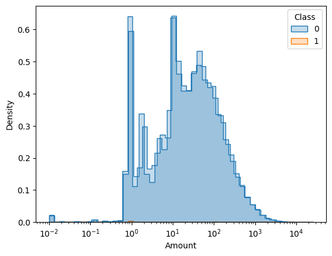

```python
import seaborn as sns
# Visualize the distribution of the fraudulent and non-fraudulent transactions
sns.histplot(data=df, x="Amount", hue="Class", bins=50, log_scale=(True, False), element="step", stat="density")
sns.histplot(data=df_anomaly, x="Amount", hue="Class", bins=50, log_scale=(True, False), element="step", stat="density")
```

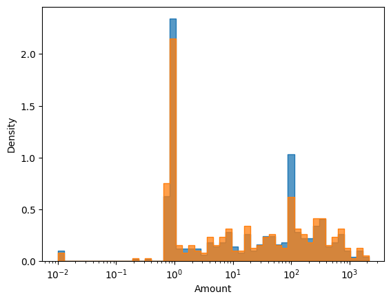

```python
# Just visualize the distribution of the fraudulent transactions
sns.histplot(data=df[df["Class"]==1], x="Amount", bins=50, log_scale=True, element="step", stat="density")
sns.histplot(data=df_anomaly[df_anomaly["Class"]==1], x="Amount", bins=50, log_scale=True, element="step", stat="density")
```

```
Explained variance ratio: [0.06745274 0.03936443]
```

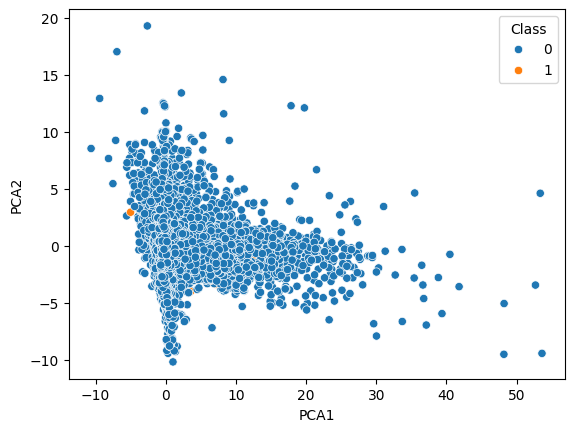

```python
from sklearn.decomposition import PCA
pca = PCA(n_components=2, random_state=SEED)
X_pca = pca.fit_transform(X_train_scaled)
df_pca = pd.DataFrame(data=X_pca, columns=['PCA1', 'PCA2'])
df_pca['Class'] = y_train.values
sns.scatterplot(data=df_pca, x='PCA1', y='PCA2', hue='Class')
print("Explained variance ratio:", pca.explained_variance_ratio_)
```

# Problem 2 — Supervised Learning (Required) — Module 4

**40 points total.**

**Use the same dataset you selected and preprocessed in Problem 1.** Your splits (train/val/test) and preprocessing choices from Problem 1 must carry forward **unchanged** here (fit on train, applied to val/test) to avoid leakage. If you switch datasets, update Problem 1 accordingly and keep provenance/splits consistent across both problems.

Build a classification pipeline and compare multiple supervised learners aligned with Module 4 (e.g., Logistic Regression, k-NN, Naive Bayes, SVM, Decision Trees, Random Forests, Gradient Boosting, and/or a shallow MLP). Use the training data for model development; reserve the held-out test set strictly for the final report. Report metrics beyond accuracy (precision, recall, F1, ROC-AUC, PR-AUC) and interpret model behavior (e.g., coefficients, feature importances, or partial effects).

## 2(a) Model development — 10 points

Implement and compare at least **three distinct families** of classifiers (e.g., LR, SVM (linear or RBF), RF/GB, k-NN, NB, shallow MLP). Use `Pipeline` to include the preprocessing from Problem 1 (e.g., `ColumnTransformer`) so all steps are reproducible and leakage-free. Provide a brief rationale for each model (linear vs non-linear boundary, robustness, interpretability).

## 2(b) Hyperparameter optimization & model selection — 20 points

Perform tuned model selection with **stratified k-fold cross-validation** (e.g., k=5 or 10). Use `GridSearchCV` or `RandomizedSearchCV` with scoring suited to your problem (e.g., F1 or PR-AUC for class imbalance). Clearly document the search space and justify key hyperparameters. Summarize CV results (mean ± std). Select the best model based on your primary metric and discuss trade-offs across secondary metrics.

## 2(c) Final model, robust evaluation & interpretation — 10 points

Retrain the selected model on **train+validation** and evaluate once on the held-out test set. Report a full classification report (precision, recall, F1), ROC and PR curves, and a confusion matrix. If classes are imbalanced, emphasize PR-AUC and class-specific metrics. Provide model interpretation (e.g., coefficients for LR, support vectors/kernels for SVM, feature importances for tree ensembles). Quantify uncertainty (e.g., bootstrap CIs) and discuss error costs and ethical considerations if relevant.

### Problem 2 — Illustrative model selection scaffold

```python
from sklearn.pipeline import Pipeline
from sklearn.compose import ColumnTransformer
from sklearn.preprocessing import StandardScaler
from sklearn.model_selection import StratifiedKFold, GridSearchCV
from sklearn.linear_model import LogisticRegression
from sklearn.naive_bayes import BernoulliNB
from sklearn.neural_network import MLPClassifier

# Fill these from Problem 1
numeric_features = list(X_train.columns)

pre = ColumnTransformer([
    ("num", StandardScaler(), numeric_features),
])

pipe_lr  = Pipeline([("pre", pre), ("clf", LogisticRegression(max_iter=2000))])
pipe_mlp = Pipeline([("pre", pre), ("clf", MLPClassifier())])
pipe_nb  = Pipeline([("pre", pre), ("clf", BernoulliNB())])

param_lr = {"clf__C": [0.01, 0.1, 1, 10], "clf__penalty": ["l2"]}
param_mlp = {"clf__hidden_layer_sizes": [50, 100, 150], "clf__max_iter": [100, 200, 300]}
param_nb = {
    "clf__alpha": np.logspace(-3, 1, 5),
    "clf__binarize": [0.0, 0.5, 1.0],
    "clf__fit_prior": [True, False]
}

cv = StratifiedKFold(n_splits=5, shuffle=True, random_state=SEED)

grid_lr  = GridSearchCV(pipe_lr,  param_lr,  scoring="f1", cv=cv, n_jobs=-1, refit=True).fit(X_train, y_train)
print("Logistic Regression best params:", grid_lr.best_params_, "best CV F1:", grid_lr.best_score_)

grid_nb  = GridSearchCV(pipe_nb,  param_nb,  scoring="f1", cv=cv, n_jobs=-1, refit=True).fit(X_train, y_train)
print("Naive Bayes best params:", grid_nb.best_params_, "best CV F1:", grid_nb.best_score_)

grid_mlp = GridSearchCV(pipe_mlp, param_mlp, scoring="f1", cv=cv, n_jobs=-1, refit=True).fit(X_train, y_train)
print("MLP best params:", grid_mlp.best_params_, "best CV F1:", grid_mlp.best_score_)
```

```
Logistic Regression best params: {'clf__C': 10, 'clf__penalty': 'l2'} best CV F1: 0.71725827631488
Naive Bayes best params: {'clf__alpha': 0.001, 'clf__binarize': 0.0, 'clf__fit_prior': True} best CV F1: 0.6533765805387576
MLP best params: {'clf__hidden_layer_sizes': 50, 'clf__max_iter': 200} best CV F1: 0.8138334714805303
```

```
Classification Report (Test Set)
              precision    recall  f1-score   support

           0      1.000     1.000     1.000     28414
           1      0.912     0.795     0.849        39

    accuracy                          1.000     28453
   macro avg      0.956     0.897     0.925     28453
weighted avg      1.000     1.000     1.000     28453
```

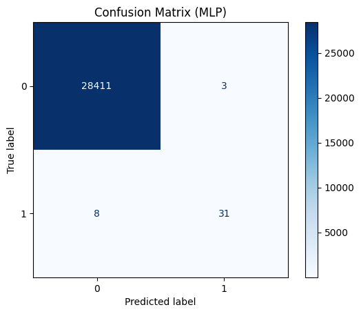

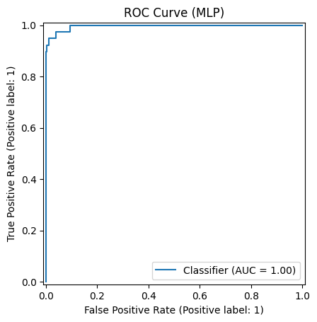

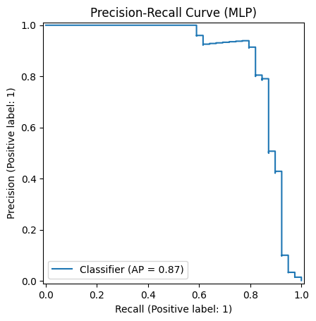

```
Model Interpretation
Layer 1 weights shape: (29, 50)
Layer 2 weights shape: (50, 1)

Top 10 important features (by average absolute weight):
V1: 0.3167
V18: 0.3018
V24: 0.2873
V25: 0.2851
V22: 0.2830
V2: 0.2699
V9: 0.2672
V19: 0.2639
V28: 0.2621
V6: 0.2604

F1 bootstrap 95% CI: [0.847, 0.847]
```

```python
import numpy as np
import pandas as pd
import matplotlib.pyplot as plt
from sklearn.metrics import (
    classification_report,
    confusion_matrix,
    ConfusionMatrixDisplay,
    RocCurveDisplay,
    PrecisionRecallDisplay,
    f1_score,
)
from sklearn.utils import resample
from sklearn.pipeline import Pipeline


# Combine train + validation and retrain best model
X_trainval = pd.concat([X_train, X_val])
y_trainval = pd.concat([y_train, y_val])

best_mlp = grid_mlp.best_estimator_
best_mlp.fit(X_trainval, y_trainval)

# Evaluate on held-out test set
y_pred = best_mlp.predict(X_test)
y_prob = best_mlp.predict_proba(X_test)[:, 1]  # for ROC/PR curves

print("Classification Report (Test Set)")
print(classification_report(y_test, y_pred, digits=3))

# Confusion matrix
cm = confusion_matrix(y_test, y_pred)
disp = ConfusionMatrixDisplay(confusion_matrix=cm)
disp.plot(cmap="Blues")
plt.title("Confusion Matrix (MLP)")
plt.show()

# ROC & Precision-Recall curves
RocCurveDisplay.from_predictions(y_test, y_prob)
plt.title("ROC Curve (MLP)")
plt.show()

PrecisionRecallDisplay.from_predictions(y_test, y_prob)
plt.title("Precision-Recall Curve (MLP)")
plt.show()

# Model interpretation
mlp_clf = best_mlp.named_steps["clf"] if isinstance(best_mlp, Pipeline) else best_mlp

print("Model Interpretation")
for i, layer_weights in enumerate(mlp_clf.coefs_):
    print(f"Layer {i+1} weights shape:", layer_weights.shape)

feature_names = X.columns if isinstance(X, pd.DataFrame) else np.arange(X.shape[1])
input_weights = mlp_clf.coefs_[0]
mean_abs_weights = np.mean(np.abs(input_weights), axis=1)
top_features_idx = np.argsort(mean_abs_weights)[::-1][:10]
print("\nTop 10 important features (by average absolute weight):")
for idx in top_features_idx:
    print(f"{feature_names[idx]}: {mean_abs_weights[idx]:.4f}")

# Uncertainty quantification via bootstrap
n_bootstraps = 1000
f1_scores = []

for _ in range(n_bootstraps):
    X_res, y_res = resample(X_test, y_test, random_state=SEED)
    y_pred_res = best_mlp.predict(X_res)
    f1_scores.append(f1_score(y_res, y_pred_res))

f1_ci = np.percentile(f1_scores, [2.5, 97.5])
print(f"\nF1 bootstrap 95% CI: [{f1_ci[0]:.3f}, {f1_ci[1]:.3f}]")
```

### Ethical considerations:

- False negatives may miss critical positive cases (under-detection).
- False positives may cause unnecessary interventions or costs.
- Use PR-AUC and class-specific recall when data are imbalanced.

# Problem 3 — Unsupervised Learning for Data Science (Optional; choose exactly one of 3/4/5) — Module 5

**40 points total.**

**Use the same dataset and preprocessing you established in Problem 1.** Your feature matrix **X** for clustering/anomaly detection must be derived from the identical cleaning, encoding, and scaling steps (fit on **train** only; apply unchanged to validation/test if used for external checks) to ensure comparability and avoid leakage.

Following Module 5, design a rigorous unsupervised workflow that compares multiple methods and validates results with **internal indices** and, when labels exist, **external indices**. Emphasize **K-Means** (with the **Elbow Method** for *k* selection), **Hierarchical Clustering** (dendrogram/Linkage), and at least one complementary approach (e.g., Gaussian Mixture via EM, **DBSCAN**). Provide clear, reproducible code and well-labeled figures.

## 3(a) Data alignment & documentation — 5 points

Summarize the **same** dataset from Problem 1 (source, license, features, target if available) and restate the exact preprocessing carried over (encoding, scaling). If labels exist, explain how they will be used **only** for external validation (e.g., ARI/NMI) after clustering.

## 3(b) Preprocessing and dimensionality reduction (optional) — 8 points

Confirm leakage-free transforms (fit on train). If you use PCA/UMAP for visualization, report explained variance (PCA) and show 2D/3D projections. Discuss why scaling matters for distance-based methods.

## 3(c) Clustering/anomaly models — 15 points

Fit at least **three** methods, including:

- **K-Means** with *k* chosen via the **Elbow Method**;
- **Hierarchical** (agglomerative) with a chosen linkage (Ward/complete/average) and a dendrogram;
- **One of:** Gaussian Mixture via EM, **DBSCAN**, or another module-approved method.  
  For DBSCAN, justify (ε, minPts) and comment on sensitivity to scale; for hierarchical, justify linkage and dendrogram cut; for GMM, justify component count.

## 3(d) Model selection, stability, and validation — 8 points

Use **internal indices** to compare models: **Silhouette**, **Calinski–Harabasz**, and **Davies–Bouldin**. For K-Means, show inertia/WCSS and an elbow plot. Discuss stability across seeds (and, where relevant, linkages/initializations). If labels exist, add **external** indices (e.g., ARI/NMI) but do **not** use labels for fitting.

## 3(e) Cluster profiling and insights — 4 points

Describe cluster sizes, centroids/medoids, and discriminative features; provide **2–3 actionable insights** (business/scientific). If you ran DBSCAN, discuss the role and meaning of the “noise” cluster.

### 3A. Data alignment & documentation

**Dataset Summary**

The dataset used in this analysis is the Credit Card Fraud Detection dataset available on Kaggle. It was originally published by the Machine Learning Group at Université Libre de Bruxelles (ULB) and is released under the CC BY-NC-SA 4.0 license, which permits non-commercial use with attribution.

The dataset contains 284,807 transactions made by European cardholders in September 2013, with each row representing a single transaction. The data include 28 anonymized numerical features (V1–V28) derived from a PCA transformation performed to protect sensitive information, along with two additional non-anonymized features:

- Time – seconds elapsed between each transaction and the first transaction in the dataset.
- Amount – transaction amount (in euros).

The target variable is Class, where:

- 0 = legitimate transaction
- 1 = fraudulent transaction

Fraudulent transactions represent only 0.172% of the dataset, making it highly imbalanced.

**Preprocessing Steps**

**Use of Labels for External Validation**

Although the dataset includes class labels, clustering was conducted in a fully unsupervised manner. The labels were used exclusively for post-clustering evaluation, to assess how well the unsupervised clusters align with known fraud/non-fraud categories. Specifically, external validation metrics such as:

- Adjusted Rand Index (ARI)
- Normalized Mutual Information (NMI)

were computed between the predicted cluster assignments and the true labels. These metrics quantify agreement between clustering results and ground truth without influencing the clustering process itself.

### 3B. preprocessing and dimensionality reduction

```
Train shape: (227617, 29) (227617,)
Val shape: (28452, 29) (28452,)
Test shape: (28453, 29) (28453,)
Fraudulent Transaction Shape Pre-Anomaly: (492, 30)
Fraudulent Transaction Shape Post-Anomaly: (387, 30)
Explained variance ratio: [0.06745274 0.03936443]
```

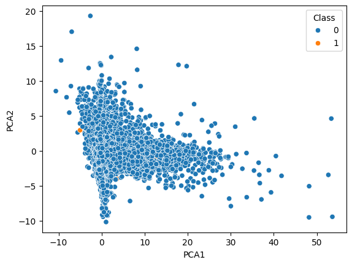

```python
from sklearn.compose import ColumnTransformer
from sklearn.preprocessing import StandardScaler
from sklearn.model_selection import train_test_split
from sklearn.ensemble import IsolationForest
from sklearn.decomposition import PCA

df_anomaly = df.copy()
iso_forest = IsolationForest(contamination=0.001, random_state=SEED)
iso_forest.fit(df_anomaly.drop(columns=[target_variable]))
df_anomaly['anomaly'] = iso_forest.predict(df_anomaly.drop(columns=[target_variable]))
df_anomaly = df_anomaly[df_anomaly['anomaly'] == 1].drop(columns=['anomaly'])

X = df_anomaly.drop(columns=[target_variable])
y = df_anomaly[target_variable]
X_train, X_temp, y_train, y_temp = train_test_split(X, y, test_size=0.2, stratify=y, random_state=SEED)
X_val, X_test, y_val, y_test = train_test_split(X_temp, y_temp, test_size=0.5, stratify=y_temp, random_state=SEED)

numeric_features = list(X_train.columns)
pre = ColumnTransformer([
    ('num', StandardScaler(), numeric_features),
])

pre.fit(X_train)
X_train_scaled = pre.transform(X_train)
X_val_scaled = pre.transform(X_val)
X_test_scaled = pre.transform(X_test)
print("Train shape:", X_train_scaled.shape, y_train.shape)
print("Val shape:", X_val_scaled.shape, y_val.shape)
print("Test shape:", X_test_scaled.shape, y_test.shape)
print("Fraudulent Transaction Shape Pre-Anomaly:", df[df["Class"] == 1].shape)
print("Fraudulent Transaction Shape Post-Anomaly:", df_anomaly[df_anomaly["Class"] == 1].shape)

pca = PCA(n_components=2, random_state=SEED)
X_pca = pca.fit_transform(X_train_scaled)
df_pca = pd.DataFrame(data=X_pca, columns=['PCA1', 'PCA2'])
df_pca['Class'] = y_train.values
sns.scatterplot(data=df_pca, x='PCA1', y='PCA2', hue='Class')
print("Explained variance ratio:", pca.explained_variance_ratio_)
```

### 3C. clustering/anomaly models

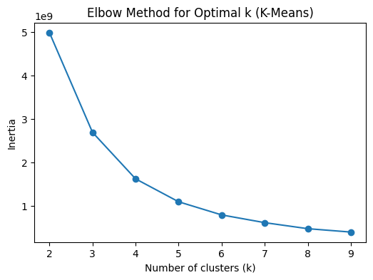

```
DBSCAN eps=0.5: clusters=12
DBSCAN eps=1.0: clusters=50
DBSCAN eps=1.5: clusters=63
HDBSCAN clusters: 551

Adjusted Rand Index (ARI):
  K-Means:  0.004
  DBSCAN:   -0.003
  HDBSCAN:  -0.002

Normalized Mutual Information (NMI):
  K-Means:  0.000
  DBSCAN:   0.000
  HDBSCAN:  0.000
```

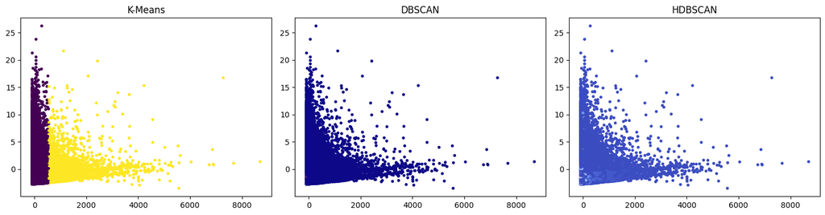

```python
import numpy as np
import pandas as pd
import matplotlib.pyplot as plt
from sklearn.preprocessing import StandardScaler
from sklearn.cluster import KMeans, DBSCAN
from sklearn.decomposition import PCA
from sklearn.metrics import adjusted_rand_score, normalized_mutual_info_score
import hdbscan

# ---------------------------
# 1. K-Means clustering
# ---------------------------
inertias = []
K = range(2, 10)
for k in K:
    kmeans = KMeans(n_clusters=k, random_state=42)
    kmeans.fit(X_train)
    inertias.append(kmeans.inertia_)

plt.figure(figsize=(6,4))
plt.plot(K, inertias, "o-")
plt.xlabel("Number of clusters (k)")
plt.ylabel("Inertia")
plt.title("Elbow Method for Optimal k (K-Means)")
plt.show()

# Choose k=3 as an example (based on elbow)
k_opt = np.argmax(inertias) + 2  # +2 to adjust for the range starting at 2
kmeans = KMeans(n_clusters=k_opt, random_state=42)
kmeans_labels = kmeans.fit_predict(X_train)

# ---------------------------
# 2. DBSCAN clustering
# ---------------------------
eps_values = [0.5, 1.0, 1.5]
min_samples = 2 * X_train.shape[1]

for eps in eps_values:
    dbscan = DBSCAN(eps=eps, min_samples=min_samples, n_jobs=-1)
    labels = dbscan.fit_predict(X_train)
    n_clusters = len(set(labels)) - (1 if -1 in labels else 0)
    print(f"DBSCAN eps={eps}: clusters={n_clusters}")

# Choose eps=1.0 as default
dbscan = DBSCAN(eps=1.0, min_samples=min_samples, n_jobs=-1)
db_labels = dbscan.fit_predict(X_train)

# ---------------------------
# 3. HDBSCAN clustering
# ---------------------------
clusterer = hdbscan.HDBSCAN(min_cluster_size=30, min_samples=10)
hdb_labels = clusterer.fit_predict(X_train)
n_hdb_clusters = len(set(hdb_labels)) - (1 if -1 in hdb_labels else 0)
print(f"HDBSCAN clusters: {n_hdb_clusters}")

# ---------------------------
# 4. External validation (optional)
# ---------------------------
if 'y_train' in locals():
    print("\nAdjusted Rand Index (ARI):")
    print(f"  K-Means:  {adjusted_rand_score(y_train, kmeans_labels):.3f}")
    print(f"  DBSCAN:   {adjusted_rand_score(y_train, db_labels):.3f}")
    print(f"  HDBSCAN:  {adjusted_rand_score(y_train, hdb_labels):.3f}")

    print("\nNormalized Mutual Information (NMI):")
    print(f"  K-Means:  {normalized_mutual_info_score(y_train, kmeans_labels):.3f}")
    print(f"  DBSCAN:   {normalized_mutual_info_score(y_train, db_labels):.3f}")
    print(f"  HDBSCAN:  {normalized_mutual_info_score(y_train, hdb_labels):.3f}")

# ---------------------------
# 5. PCA projection for visualization
# ---------------------------
pca = PCA(n_components=2)
X_pca = pca.fit_transform(X_train)

fig, axes = plt.subplots(1, 3, figsize=(15, 4))
axes[0].scatter(X_pca[:, 0], X_pca[:, 1], c=kmeans_labels, s=8, cmap='viridis')
axes[0].set_title("K-Means")

axes[1].scatter(X_pca[:, 0], X_pca[:, 1], c=db_labels, s=8, cmap='plasma')
axes[1].set_title("DBSCAN")

axes[2].scatter(X_pca[:, 0], X_pca[:, 1], c=hdb_labels, s=8, cmap='coolwarm')
axes[2].set_title("HDBSCAN")

plt.tight_layout()
plt.show()
```

### 3D. Model selection, stability, and validation

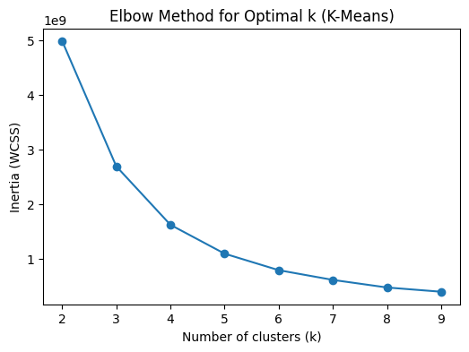

```
 Internal Indices Comparison
               Model  Silhouette  Calinski-Harabasz  Davies-Bouldin  \
0  K-Means (seed=42)       0.907         302708.794           0.480
1             DBSCAN       0.333           2454.324           1.071
2            HDBSCAN       0.078         110600.148           1.608

        Inertia
0  4.993962e+09
1           NaN
2           NaN

 External Indices (using true labels)
K-Means ARI:  0.004
K-Means NMI:  0.000
DBSCAN ARI:   -0.003
HDBSCAN ARI:  -0.002
DBSCAN NMI:   0.000
HDBSCAN NMI:  0.000
```

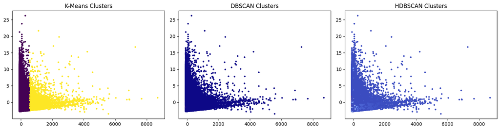

```python
import numpy as np
import pandas as pd
import matplotlib.pyplot as plt
from sklearn.preprocessing import StandardScaler
from sklearn.cluster import KMeans, DBSCAN
from sklearn.decomposition import PCA
from sklearn.metrics import (
    silhouette_score, calinski_harabasz_score, davies_bouldin_score,
    adjusted_rand_score, normalized_mutual_info_score
)
import hdbscan

# ---------------------------
# 2. K-Means: Elbow method
# ---------------------------
inertias = []
K = range(2, 10)
for k in K:
    kmeans = KMeans(n_clusters=k, random_state=42)
    kmeans.fit(X_train)
    inertias.append(kmeans.inertia_)

plt.figure(figsize=(6,4))
plt.plot(K, inertias, "o-")
plt.xlabel("Number of clusters (k)")
plt.ylabel("Inertia (WCSS)")
plt.title("Elbow Method for Optimal k (K-Means)")
plt.show()

# Choose k=3 for demonstration
k_opt = np.argmax(inertias) + 2  # +2 to adjust for the range starting at 2
# k_opt = 3

# ---------------------------
# 3. Fit all clustering models
# ---------------------------
results = []

# K-Means (test across seeds for stability)
kmeans = KMeans(n_clusters=k_opt, random_state=SEED)
labels = kmeans.fit_predict(X_train)
valid_mask = labels != -1  # DBSCAN/HDBSCAN might have noise; KMeans doesn't, but this keeps code generic

results.append({
    "Model": f"K-Means (seed={SEED})",
    "Silhouette": silhouette_score(X_train[valid_mask], labels[valid_mask]),
    "Calinski-Harabasz": calinski_harabasz_score(X_train[valid_mask], labels[valid_mask]),
    "Davies-Bouldin": davies_bouldin_score(X_train[valid_mask], labels[valid_mask]),
    "Inertia": kmeans.inertia_
})

# DBSCAN
dbscan = DBSCAN(eps=1.0, min_samples=2 * X_train.shape[1], n_jobs=-1)
db_labels = dbscan.fit_predict(X_train)
if len(set(db_labels)) > 1:
    valid_mask = db_labels != -1
    results.append({
        "Model": "DBSCAN",
        "Silhouette": silhouette_score(X_train[valid_mask], db_labels[valid_mask]),
        "Calinski-Harabasz": calinski_harabasz_score(X_train[valid_mask], db_labels[valid_mask]),
        "Davies-Bouldin": davies_bouldin_score(X_train[valid_mask], db_labels[valid_mask]),
        "Inertia": np.nan
    })

# HDBSCAN
hdb = hdbscan.HDBSCAN(min_cluster_size=30, min_samples=10)
hdb_labels = hdb.fit_predict(X_train)
if len(set(hdb_labels)) > 1:
    valid_mask = hdb_labels != -1
    results.append({
        "Model": "HDBSCAN",
        "Silhouette": silhouette_score(X_train[valid_mask], hdb_labels[valid_mask]),
        "Calinski-Harabasz": calinski_harabasz_score(X_train[valid_mask], hdb_labels[valid_mask]),
        "Davies-Bouldin": davies_bouldin_score(X_train[valid_mask], hdb_labels[valid_mask]),
        "Inertia": np.nan
    })

# ---------------------------
# 4. Convert results to DataFrame
# ---------------------------
df_results = pd.DataFrame(results)
print("\n Internal Indices Comparison ")
print(df_results.round(3))

# ---------------------------
# 5. Optional: External Validation (if y_train exists)
# ---------------------------
if 'y_train' in locals():
    print("\n External Indices (using true labels) ")
    print(f"K-Means ARI:  {adjusted_rand_score(y_train, kmeans.labels_):.3f}")
    print(f"K-Means NMI:  {normalized_mutual_info_score(y_train, kmeans.labels_):.3f}")
    print(f"DBSCAN ARI:   {adjusted_rand_score(y_train, db_labels):.3f}")
    print(f"HDBSCAN ARI:  {adjusted_rand_score(y_train, hdb_labels):.3f}")
    print(f"DBSCAN NMI:   {normalized_mutual_info_score(y_train, db_labels):.3f}")
    print(f"HDBSCAN NMI:  {normalized_mutual_info_score(y_train, hdb_labels):.3f}")

# ---------------------------
# 6. PCA visualization
# ---------------------------
pca = PCA(n_components=2)
X_pca = pca.fit_transform(X_train)

fig, axes = plt.subplots(1, 3, figsize=(15, 4))
axes[0].scatter(X_pca[:, 0], X_pca[:, 1], c=kmeans.labels_, s=6, cmap='viridis')
axes[0].set_title("K-Means Clusters")

axes[1].scatter(X_pca[:, 0], X_pca[:, 1], c=db_labels, s=6, cmap='plasma')
axes[1].set_title("DBSCAN Clusters")

axes[2].scatter(X_pca[:, 0], X_pca[:, 1], c=hdb_labels, s=6, cmap='coolwarm')
axes[2].set_title("HDBSCAN Clusters")

plt.tight_layout()
plt.show()
```

### 3E. cluster profiling and insights

```python
import numpy as np
import pandas as pd

# Assume we already have labels for each clustering model
cluster_summary = pd.DataFrame({
    "KMeans": pd.Series(kmeans.labels_).value_counts().sort_index(),
    "DBSCAN": pd.Series(db_labels).value_counts().sort_index(),
    "HDBSCAN": pd.Series(hdb_labels).value_counts().sort_index()
}).fillna(0).astype(int)

print("=== Cluster Sizes (number of samples per cluster) ===")
print(cluster_summary)
```

```
=== Cluster Sizes (number of samples per cluster) ===
      KMeans  DBSCAN  HDBSCAN
-1         0  213504   167903
 0    222571     715       55
 1      5046    1232       50
 2         0     464       41
 3         0      84       77
...      ...     ...      ...
 546       0       0      196
 547       0       0       78
 548       0       0      114
 549       0       0       63
 550       0       0       76

[552 rows x 3 columns]
```

```python
cluster_features = pd.DataFrame(X_train, columns=X_train.columns)
cluster_features["Cluster"] = kmeans.labels_

feature_summary = cluster_features.groupby("Cluster").mean()
feature_diffs = feature_summary.max() - feature_summary.min()
top_features = feature_diffs.sort_values(ascending=False).head(10)

print("\n=== Top Discriminative Features (K-Means) ===")
print(top_features)
```

```
=== Top Discriminative Features (K-Means) ===
Amount    1160.174035
V2           3.940829
V5           2.248238
V7           2.238552
V1           1.928304
V20          1.591065
V3           1.559279
V6           1.174879
V4           0.627180
V8           0.557294
dtype: float64
```

## References

Bishop (2006); Breiman (2001); Brockman et al. (2016); Calinski & Harabasz (1974); Cortes & Vapnik (1995); Dempster et al. (1977); Fawcett (2006); Hastie, Tibshirani & Friedman (2009); He et al. (2016); Krizhevsky et al. (2012); MacQueen (1967); Pedregosa et al. (2011); Rousseeuw (1987); Sutton & Barto (2018); Vaswani et al. (2017); Wolf et al. (2020).